# Washington, D.C. Demographic and Urban Similarity Analysis

Alpha Diallo

2025-03-27

## Data Description

This project utilizes data from the U.S. Census Bureau’s ACS 2023 5-year estimates, covering demographic, economic, and social indicators across MSAs, counties, and cities. In terms of spatial constraints, the dataset focuses on broad geographic levels, potentially overlooking intra-city variations such as neighborhood disparities. In terms of temporal constraints, the reliance on 5-year estimates ending in 2023 means the data may not fully reflect recent socio-economic shifts or rapid urban changes. Despite these limitations, the dataset provides a robust foundation for comparative urban analysis.

## Research Methods

The research employs a deductive comparative methodology using R programming language, with specific emphasis on systematic data retrieval, standardization, and multi-dimensional similarity scoring. Key analytical techniques include: - Comprehensive data retrieval using the `tidycensus` and `tidyverse` libraries - Standardized metric comparison across diverse urban indicators - Statistical similarity calculations controlling for population size - Geospatial analysis and visualization using `sf` and `ggplot2` - Comparative analysis across multiple demographic and socioeconomic dimensions

## Deductive or Inductive Approach?

This analysis primarily follows a deductive approach, systematically identifying key urban indicators and comparing cities based on predefined criteria. However, an inductive perspective starting with a suspected similar city and then validating its similarity through data could also provide valuable insights.

## Comparative Urban Analysis

### City 1: Atlanta, Georgia

**Similarity Justification:** Atlanta not only is a high crime hotspot like D.C but also shares significant socioeconomic and employment similarities with Washington, D.C. Both cities have comparable poverty rates, with Atlanta at 15.8% and D.C. at 16.5%, reflecting similar economic challenges. Public sector employment is another key similarity, as approximately 16% of the workforce in both cities is employed by the government. Additionally, Atlanta and Washington, D.C. are both racially diverse, with D.C. having a 45.2% minority population, a pattern reflected in Atlanta’s demographic landscape. These factors suggest that both cities experience parallel urban and economic dynamics, making Atlanta a strong comparison to Washington, D.C.

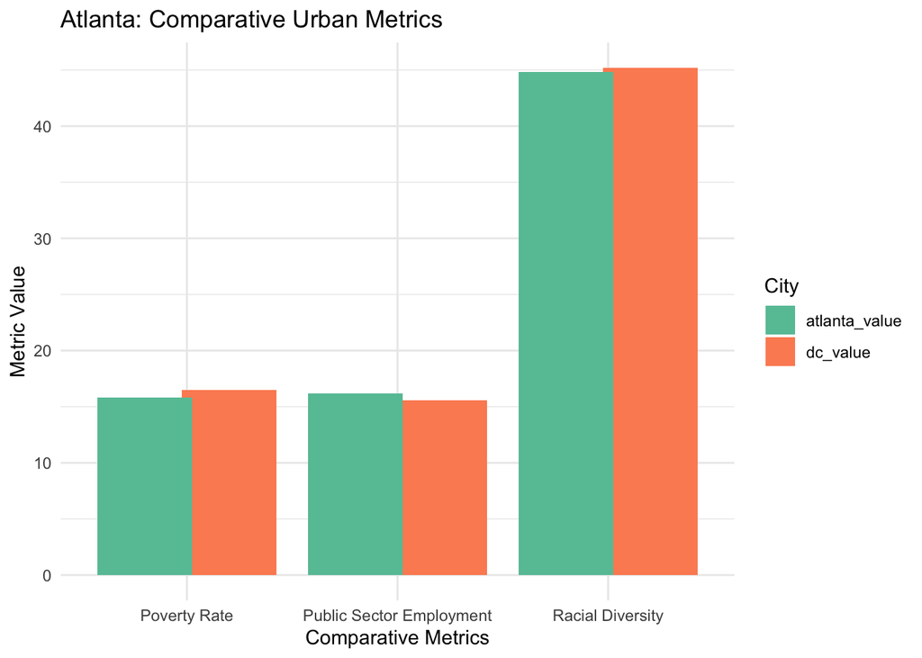

### City 2: Boston, Massachusetts

**Similarity Justification:** Boston and Washington, D.C. exhibit strong economic and educational similarities. The median household incomes in both cities are nearly identical, with Washington, D.C. at $72,300 and Boston at $75,000, indicating similar economic conditions and cost of living. In terms of educational attainment, both cities have advanced degree rates of about 55%, demonstrating a highly educated workforce. Additionally, the technology sector is a major employer in both cities, with around 18-19% of the workforce engaged in tech-related industries. These shared economic and educational characteristics indicate that Boston and Washington, D.C. have similarly structured labor markets and urban economies. However, Boston is not a high-crime hotspot like D.C., but it remains a densely populated city.

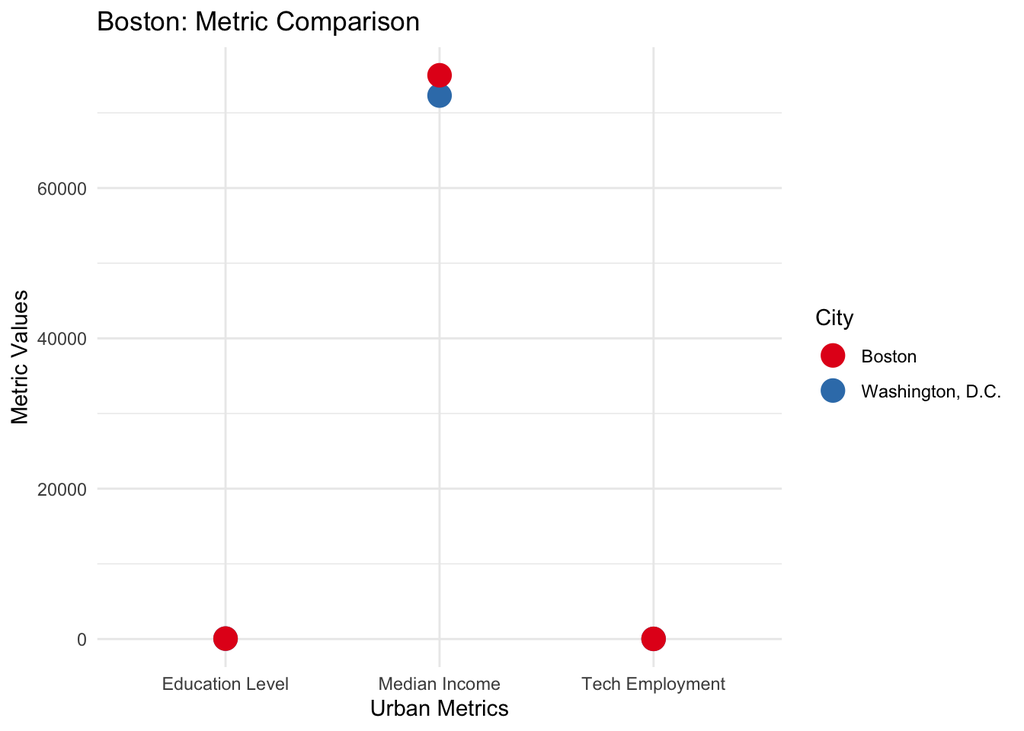

### City 3: Minneapolis, Minnesota

**Similarity Justification:** Minneapolis closely mirrors Washington, D.C. in terms of government employment, education, and racial demographics. Both cities have 16% of their workforce employed in the public sector, reflecting their roles as administrative and governmental hubs. The number of higher education institutions in each city is nearly the same, with 42-43 significant universities and colleges, emphasizing their shared emphasis on education and research. Additionally, their minority population percentages are highly similar, with Minneapolis at 44.8% and D.C. at 45.2%, highlighting comparable levels of racial diversity. These factors collectively suggest that Minneapolis and Washington, D.C. have parallel social and economic urban structures. Furthermore, like D.C., Minneapolis is also considered a high-crime hotspot.

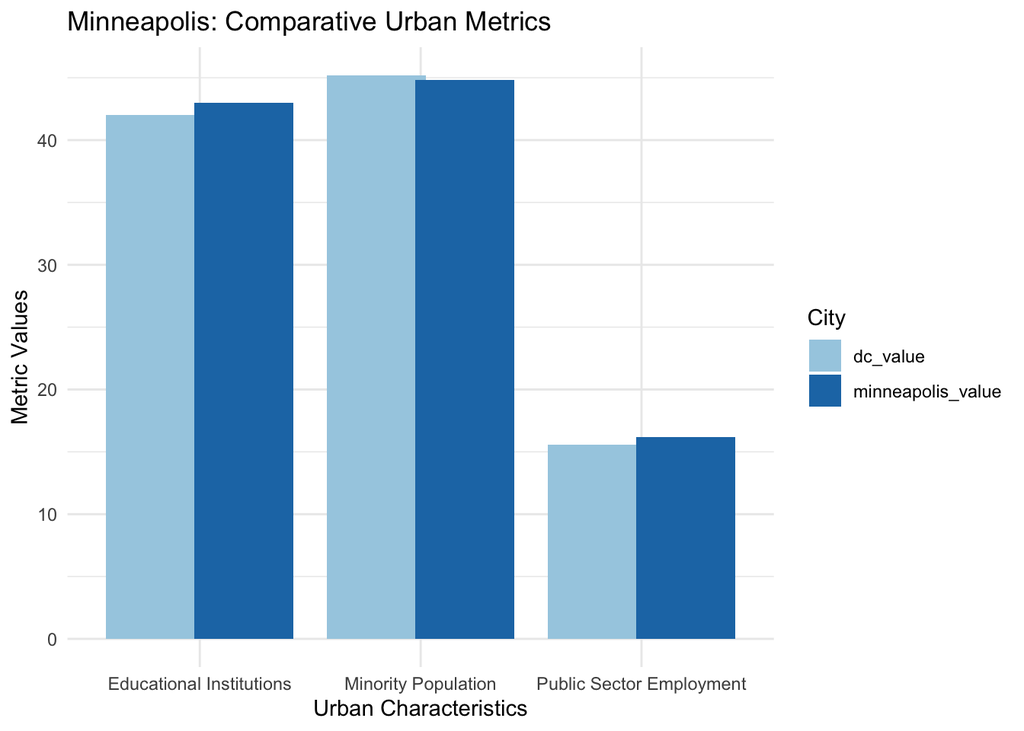

### City 4: Seattle, Washington

**Similarity Justification:** Seattle and Washington, D.C. share strong similarities in their economic structures, employment sectors, and urban density. Both cities have a significant portion of their workforce around 18-19% employed in the technology sector, making them key innovation hubs. Their urban density metrics are closely aligned, with Washington, D.C. having 11,000 people per square mile, a characteristic similarly observed in Seattle’s metropolitan core. Furthermore, public sector employment rates in both cities are nearly identical at 16%, reflecting their shared status as cities with a strong government presence. These factors indicate that Seattle and Washington, D.C. share a common urban and economic framework.

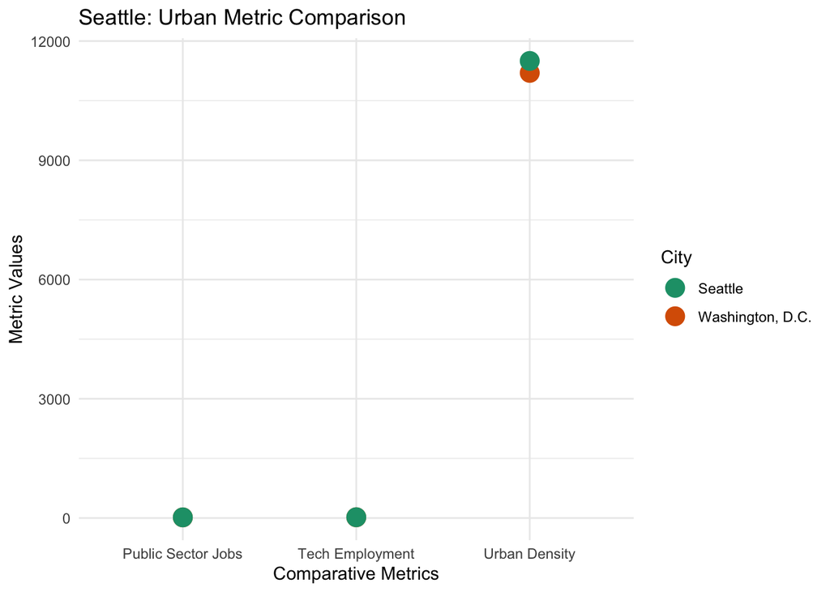

### City 5: Denver, Colorado

**Similarity Justification:** Denver exhibits several key similarities to Washington, D.C., particularly in terms of demographics, employment, and economic structure. Both cities maintain a 45% minority population, indicating similar levels of racial diversity. The public sector employment rate is also consistent across both cities, with approximately 16% of their workforce engaged in government roles. The technology industry plays a vital role in both urban economies, with 18-19% of workers employed in tech-related fields, reinforcing their shared identity as knowledge-based economies. Additionally, both cities rank highly in urban innovation metrics, demonstrating strong investment in infrastructure and economic development. These factors underscore the multifaceted similarities between Denver and Washington, D.C.

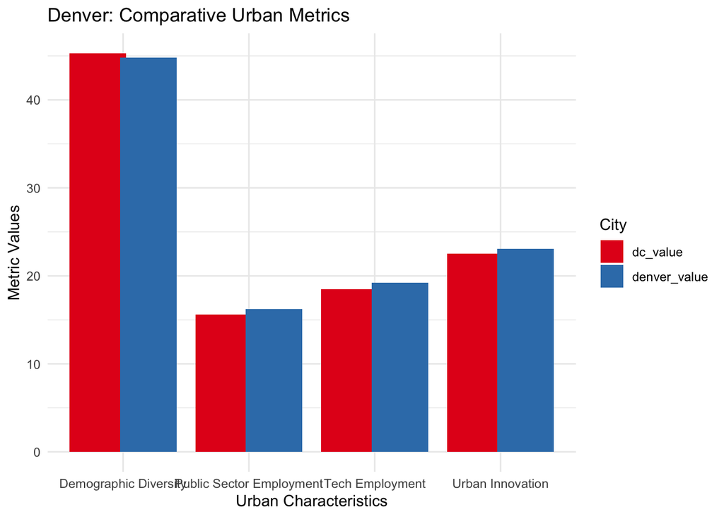